# Quickstart

Note

This very simple tutorial will guide you through the most basic functionalities of **pyepidemics**, ie building and manipulating a SIR model

##### Developer import

```
%matplotlib inline
%load_ext autoreload
%autoreload 2

# Developer import
import sys
sys.path.append("../../")
```

##### On Google Colab

Uncomment the following line to install the library locally

```
# !pip install pyepidemics
```

##### Verify the library is correctly installed

```
import pyepidemics
```

# Building a SIR model

## Quickstart

Simply imports the pre-coded SIR model from the bank of models

```
from pyepidemics.models import SIR

N = 1000 # Thousand persons
beta = 3/4 # One person contaminates 3/4 person per day
gamma = 1/4 # One person stay infected for 4 days

sir = SIR(N,beta,gamma)
```

You can then make predictions using this model

```
states = sir.solve()
```

`states` is a custom object, ie a Pandas DataFrame with more features adapted to our case

```
type(states)
```

```
pyepidemics.models.states.CompartmentStates
```

Among those features are visualization with simple but efficient functions like .show()

```
states.show(plotly = False)
```

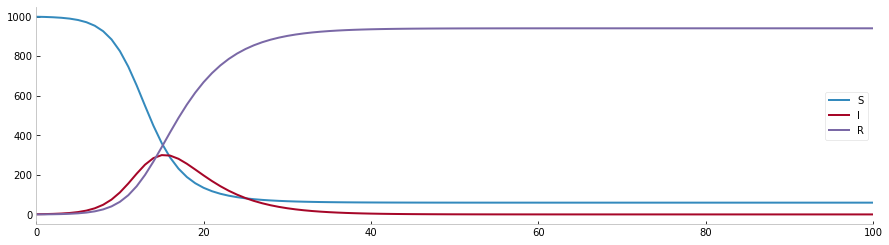

Yet states is also a DataFrame you can use and manipulate as usual where the population in each compartment is stored

```
states.head()
```

|  | S | I | R |
| --- | --- | --- | --- |
| 0 | 999.000000 | 1.000000 | 0.000000 |
| 1 | 998.028875 | 1.646935 | 0.324190 |
| 2 | 996.432306 | 2.709836 | 0.857858 |
| 3 | 993.812926 | 4.451810 | 1.735264 |
| 4 | 989.530091 | 7.295041 | 3.174868 |

For example you can find the date of the epidemic peak easily with :

```
states["I"].idxmax()
```

```
15
```

You can also visualize the epidemic curves in proportions (curves can be reordered or selected using Pandas indexing)

```
states[["I","R","S"]].show_evolution_norm(plotly = False)
```

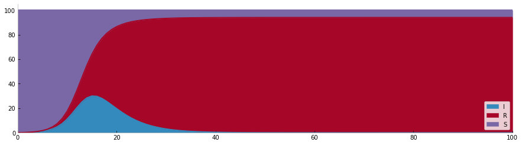

# To go further

You can learn more about those models in other tutorials like:

- [Beyond SIR modeling](https://collectif-codata.github.io/pyepidemics/tutorials/beyond-sir/)
- [Creating a custom model](https://collectif-codata.github.io/pyepidemics/tutorials/custom_model/)
- [Calibrating models on real data](https://collectif-codata.github.io/pyepidemics/tutorials/calibration/)

## Advanced users

### Visualization with plotly

Plotly is a super nice visualization library to access dynamic plots. You can easily visualize with plotly using `plotly=True` with other visualization features :

```
states.show(plotly = True)
```

[interactive chart not shown]

You can separate on each row (respectively column with the argument `facet_column`) to make it more readable

```
states.show(facet_row = "compartment")
```

[interactive chart not shown]

You can also group epidemic curves together using the argument `group`, which is super useful to visualize together curves of the same scale.

```
states.show(group = {"Infections":["I"],"Population":["S","R"]})
```

[interactive chart not shown]

There are other arguments like `return_plot` to get the plotly figure, which you can use in [Dash](https://plotly.com/dash/) or [Streamlit](https://streamlit.io/) apps.

### Controlling the `solve()` function

When you solve the differential equation it implicitly use `I0=1`, ie starting with `S0 = N-1` and `I0 =1`, you can change that behavior by passing an `init_state` to the solve equation as shown below

This will be interpreted as `init_state = {"S":N-100,"I":100,"R":0}`

```
sir.solve(init_state = 100).show(plotly = False)
```

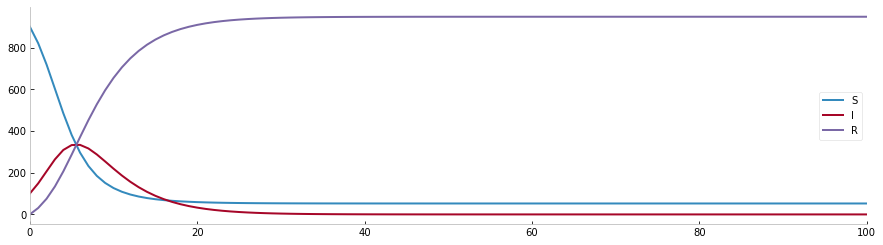

Which is equivalent to the following expressions

```
sir.solve(init_state = (900,100,0))
sir.solve(init_state = {"S":900,"I":100,"R":0})
sir.solve(init_state = {"S":900,"I":100}) # Any compartment not initialized is implicitly = 0
```

|  | S | I | R |
| --- | --- | --- | --- |
| 0 | 900.000000 | 100.000000 | 0.000000 |
| 1 | 820.473669 | 148.688683 | 30.837648 |
| 2 | 718.404927 | 206.474611 | 75.120462 |
| 3 | 601.974672 | 263.965528 | 134.059800 |
| 4 | 485.051804 | 308.901834 | 206.046362 |
| ... | ... | ... | ... |
| 96 | 52.442809 | 0.000004 | 947.557187 |
| 97 | 52.442809 | 0.000003 | 947.557188 |
| 98 | 52.442809 | 0.000002 | 947.557189 |
| 99 | 52.442809 | 0.000002 | 947.557189 |
| 100 | 52.442809 | 0.000002 | 947.557190 |

101 rows Ã— 3 columns